# HW 5 Submission

## Shashank Puthanveedu (MB12)

```python
# Importing the required packages

import pandas as pd
import datetime as dt
import numpy as np
import plotly.graph_objects as go
import matplotlib.pyplot as plt

pd.set_option('display.max_columns', 500)
```

### Exercise 1 - Data Cleaning

#### 1.1

```python
# Reading the data sheet into a pandas data frame
food_inspection_data = pd.read_csv('Food_Inspection.csv')
```

```python
# Top 5 rows of the data frame created from the sheet
food_inspection_data.head(3)
```

|  | Establishment ID | Name | Address 1 | Address 2 | City | Zip | Inspection Date | Inspection Results | Food from Approved Source (C) | Food Protected from Contamination (C) | Ill Workers Restricted (C) | Proper Hand Washing (C) | Cooling Time and Temperature (C) | Cold Holding Temperature (C) | Hot Holding Temperature (C) | Cooking Time and Temperature (C) | Reheating Time and Temperature (C) | Hot and Cold Running Water Provided (C) | Proper Sewage Disposal (C) | Toxic Substances & Pesticides | Rodent and Insects | Nutritional Labeling | Trans Fat Ban | No-Smoking Sign Posted | Inspection Type | Owner | Category | Type | Latitude | … |
| --- | --- | --- | --- | --- | --- | --- | --- | --- | --- | --- | --- | --- | --- | --- | --- | --- | --- | --- | --- | --- | --- | --- | --- | --- | --- | --- | --- | --- | --- | --- |
| 0 | 18628 | SUBWAY #22916 | 12193 DARNESTOWN RD. | NaN | GAITHERSBURG | 20878 | 12/19/2018 | No Critical Violations Noted | In Compliance | In Compliance | In Compliance | In Compliance | In Compliance | In Compliance | In Compliance | In Compliance | In Compliance | In Compliance | In Compliance | In Compliance | In Compliance | Not applicable | In Compliance | In Compliance | Monitoring | P. N. ENTERPRISES, LLC | Restaurant | Food | 39.1179 | … |
| 1 | 1059 | GIANT FOOD #0192 | 18250 FLOWER HILL WAY | NaN | GAITHERSBURG | 20879 | 12/19/2018 | Critical Violations Corrected | In Compliance | In Compliance | In Compliance | Out of Compliance | Out of Compliance | Out of Compliance | In Compliance | In Compliance | In Compliance | In Compliance | In Compliance | In Compliance | In Compliance | Not applicable | In Compliance | In Compliance | Comprehensive | GIANT OF MARYLAND, LLC | Market | Food | 39.1551 | … |
| 2 | 20933 | PIZZA BOLIS | 7831 EASTERN AVE. | NaN | SILVER SPRING | 20910 | 12/19/2018 | No Critical Violations Noted | In Compliance | In Compliance | In Compliance | In Compliance | In Compliance | In Compliance | In Compliance | In Compliance | In Compliance | In Compliance | In Compliance | In Compliance | In Compliance | Not applicable | In Compliance | In Compliance | Monitoring | K.M.MG INC | Restaurant | Food | 38.9853 | … |

```python
# Replacing NaNs and missing values with 'No Data Found'
food_inspection_data = food_inspection_data.fillna('No Data Found')
```

```python
# Extracting the unique categories
unique_category_data = pd.DataFrame(food_inspection_data['Category'].unique())
```

```python
unique_category_data
```

|  | 0 |
| --- | --- |
| 0 | Restaurant |
| 1 | Market |
| 2 | Caterer |
| 3 | Non-Profit |
| 4 | Public School- Other |
| 5 | No Data Found |
| 6 | Public School- Elementary |
| 7 | Hospital |
| 8 | Public School- Middle |
| 9 | Assisted Living |
| 10 | Private School |
| 11 | Nursing Home |
| 12 | Public School- High |
| 13 | Carry Out |
| 14 | Farmers Market |
| 15 | Snack Bar |
| 16 | Institution |
| 17 | Excluded Organization |
| 18 | Seasonal |
| 19 | Mobile Unit |

**Restaurant, Caterer, Carry Out, Farmers Market, Snacks Bar, Mobile Unit** and **Seasonal** are the values in category column that can be associated with a restaurant.

```python
unique_categories = ['Restaurant', 'Caterer', 'Carry Out', 'Farmers Market', 'Snacks Bar', 'Mobile Unit', 'Seasonal']
```

```python
# Create flag for restaurants
for type in unique_categories:
    food_inspection_data.loc[food_inspection_data['Category'].str.contains(type), 'Is_Restaurant'] = 'Y'
food_inspection_data = food_inspection_data.fillna('N')
```

```python
# Updated Data Frame after Step 1.1
food_inspection_data.head(5)
```

|  | Establishment ID | Name | Address 1 | Address 2 | City | Zip | Inspection Date | Inspection Results | Food from Approved Source (C) | Food Protected from Contamination (C) | Ill Workers Restricted (C) | Proper Hand Washing (C) | Cooling Time and Temperature (C) | Cold Holding Temperature (C) | Hot Holding Temperature (C) | Cooking Time and Temperature (C) | Reheating Time and Temperature (C) | Hot and Cold Running Water Provided (C) | Proper Sewage Disposal (C) | Toxic Substances & Pesticides | Rodent and Insects | Nutritional Labeling | Trans Fat Ban | No-Smoking Sign Posted | Inspection Type | Owner | Category | Type | Latitude | … |
| --- | --- | --- | --- | --- | --- | --- | --- | --- | --- | --- | --- | --- | --- | --- | --- | --- | --- | --- | --- | --- | --- | --- | --- | --- | --- | --- | --- | --- | --- | --- |
| 0 | 18628 | SUBWAY #22916 | 12193 DARNESTOWN RD. | No Data Found | GAITHERSBURG | 20878 | 12/19/2018 | No Critical Violations Noted | In Compliance | In Compliance | In Compliance | In Compliance | In Compliance | In Compliance | In Compliance | In Compliance | In Compliance | In Compliance | In Compliance | In Compliance | In Compliance | Not applicable | In Compliance | In Compliance | Monitoring | P. N. ENTERPRISES, LLC | Restaurant | Food | 39.1179 | … |
| 1 | 1059 | GIANT FOOD #0192 | 18250 FLOWER HILL WAY | No Data Found | GAITHERSBURG | 20879 | 12/19/2018 | Critical Violations Corrected | In Compliance | In Compliance | In Compliance | Out of Compliance | Out of Compliance | Out of Compliance | In Compliance | In Compliance | In Compliance | In Compliance | In Compliance | In Compliance | In Compliance | Not applicable | In Compliance | In Compliance | Comprehensive | GIANT OF MARYLAND, LLC | Market | Food | 39.1551 | … |
| 2 | 20933 | PIZZA BOLIS | 7831 EASTERN AVE. | No Data Found | SILVER SPRING | 20910 | 12/19/2018 | No Critical Violations Noted | In Compliance | In Compliance | In Compliance | In Compliance | In Compliance | In Compliance | In Compliance | In Compliance | In Compliance | In Compliance | In Compliance | In Compliance | In Compliance | Not applicable | In Compliance | In Compliance | Monitoring | K.M.MG INC | Restaurant | Food | 38.9853 | … |
| 3 | 22217 | GREENE TURTLE | 18101 TOWN CENTER DR | No Data Found | OLNEY | 20832 | 12/13/2017 | No Critical Violations Noted | In Compliance | In Compliance | In Compliance | In Compliance | In Compliance | In Compliance | In Compliance | In Compliance | In Compliance | In Compliance | In Compliance | In Compliance | In Compliance | Not applicable | In Compliance | In Compliance | Comprehensive | OLNEY GT, LLC. | Restaurant | Food | 39.1519 | … |
| 4 | 28408 | CRAVE | 7101 DEMOCRACY BLVD | SPACE #FC | BETHESDA | 20817 | 12/13/2018 | No Critical Violations Noted | In Compliance | In Compliance | In Compliance | In Compliance | In Compliance | In Compliance | In Compliance | In Compliance | In Compliance | In Compliance | In Compliance | In Compliance | Out of Compliance | Not applicable | In Compliance | In Compliance | Monitoring | CRAVE RESTAURANT BETHESDA LLC | Restaurant | Food | 39.0221 | … |

### 1.2

```python
# Converting Inspection Date to datetime
food_inspection_data['Inspection Date']= pd.to_datetime(food_inspection_data['Inspection Date'])
```

```python
# Creating a new column for storing the year
food_inspection_data['Inspection Year'] = pd.DatetimeIndex(food_inspection_data['Inspection Date']).year
```

```python
# Creating a new column for storing the month
food_inspection_data['Inspection Month'] = pd.DatetimeIndex(food_inspection_data['Inspection Date']).month
```

```python
# Creating a new column to store the year-month information
food_inspection_data['Inspection Year/Month'] = pd.to_datetime(food_inspection_data['Inspection Date']).dt.to_period('M')
```

```python
# Updated Data Frame after Step 1.2
food_inspection_data.head(5)
```

|  | Establishment ID | Name | Address 1 | Address 2 | City | Zip | Inspection Date | Inspection Results | Food from Approved Source (C) | Food Protected from Contamination (C) | Ill Workers Restricted (C) | Proper Hand Washing (C) | Cooling Time and Temperature (C) | Cold Holding Temperature (C) | Hot Holding Temperature (C) | Cooking Time and Temperature (C) | Reheating Time and Temperature (C) | Hot and Cold Running Water Provided (C) | Proper Sewage Disposal (C) | Toxic Substances & Pesticides | Rodent and Insects | Nutritional Labeling | Trans Fat Ban | No-Smoking Sign Posted | Inspection Type | Owner | Category | Type | Latitude | … |
| --- | --- | --- | --- | --- | --- | --- | --- | --- | --- | --- | --- | --- | --- | --- | --- | --- | --- | --- | --- | --- | --- | --- | --- | --- | --- | --- | --- | --- | --- | --- |
| 0 | 18628 | SUBWAY #22916 | 12193 DARNESTOWN RD. | No Data Found | GAITHERSBURG | 20878 | 2018-12-19 | No Critical Violations Noted | In Compliance | In Compliance | In Compliance | In Compliance | In Compliance | In Compliance | In Compliance | In Compliance | In Compliance | In Compliance | In Compliance | In Compliance | In Compliance | Not applicable | In Compliance | In Compliance | Monitoring | P. N. ENTERPRISES, LLC | Restaurant | Food | 39.1179 | … |
| 1 | 1059 | GIANT FOOD #0192 | 18250 FLOWER HILL WAY | No Data Found | GAITHERSBURG | 20879 | 2018-12-19 | Critical Violations Corrected | In Compliance | In Compliance | In Compliance | Out of Compliance | Out of Compliance | Out of Compliance | In Compliance | In Compliance | In Compliance | In Compliance | In Compliance | In Compliance | In Compliance | Not applicable | In Compliance | In Compliance | Comprehensive | GIANT OF MARYLAND, LLC | Market | Food | 39.1551 | … |
| 2 | 20933 | PIZZA BOLIS | 7831 EASTERN AVE. | No Data Found | SILVER SPRING | 20910 | 2018-12-19 | No Critical Violations Noted | In Compliance | In Compliance | In Compliance | In Compliance | In Compliance | In Compliance | In Compliance | In Compliance | In Compliance | In Compliance | In Compliance | In Compliance | In Compliance | Not applicable | In Compliance | In Compliance | Monitoring | K.M.MG INC | Restaurant | Food | 38.9853 | … |
| 3 | 22217 | GREENE TURTLE | 18101 TOWN CENTER DR | No Data Found | OLNEY | 20832 | 2017-12-13 | No Critical Violations Noted | In Compliance | In Compliance | In Compliance | In Compliance | In Compliance | In Compliance | In Compliance | In Compliance | In Compliance | In Compliance | In Compliance | In Compliance | In Compliance | Not applicable | In Compliance | In Compliance | Comprehensive | OLNEY GT, LLC. | Restaurant | Food | 39.1519 | … |
| 4 | 28408 | CRAVE | 7101 DEMOCRACY BLVD | SPACE #FC | BETHESDA | 20817 | 2018-12-13 | No Critical Violations Noted | In Compliance | In Compliance | In Compliance | In Compliance | In Compliance | In Compliance | In Compliance | In Compliance | In Compliance | In Compliance | In Compliance | In Compliance | Out of Compliance | Not applicable | In Compliance | In Compliance | Monitoring | CRAVE RESTAURANT BETHESDA LLC | Restaurant | Food | 39.0221 | … |

### 1.3

```python
# Creating a list of compliance types
compliance_type = []
for i in range(len(food_inspection_data.columns)):
    if '(C)' in food_inspection_data.columns[i]:
        compliance_type.append(food_inspection_data.columns[i])
```

```python
compliance_type.extend(['Toxic Substances & Pesticides','Rodent and Insects','Nutritional Labeling','Trans Fat Ban','No-Smoking Sign Posted'])
```

```python
# Creating dummy variables for the types of compliances
new_dummy_columns = []
for column in compliance_type:
    food_inspection_data.loc[food_inspection_data[column].str.contains('In Compliance'), str(column)+' compliance'] = 0
    food_inspection_data.loc[food_inspection_data[column].str.contains('Out of Compliance'), str(column)+' compliance'] = 1
    new_dummy_columns.append(str(column)+' compliance')
food_inspection_data = food_inspection_data.fillna(np.nan)
```

```python
# Dropping the Categorical Variable columns, keeping only the dummy variables in new Data Frame
food_inspection_data_dummy = food_inspection_data.drop(columns=compliance_type)
```

```python
# Updated Data Frame after Step 1.3
food_inspection_data_dummy.head(5)
```

|  | Establishment ID | Name | Address 1 | Address 2 | City | Zip | Inspection Date | Inspection Results | Inspection Type | Owner | Category | Type | Latitude | Longitude | Location | Is_Restaurant | Inspection Year | Inspection Month | Inspection Year/Month | Food from Approved Source (C) compliance | Food Protected from Contamination (C) compliance | Ill Workers Restricted (C) compliance | Proper Hand Washing (C) compliance | Cooling Time and Temperature (C) compliance | Cold Holding Temperature (C) compliance | Hot Holding Temperature (C) compliance | Cooking Time and Temperature (C) compliance | Reheating Time and Temperature (C) compliance | Hot and Cold Running Water Provided (C) compliance | … |
| --- | --- | --- | --- | --- | --- | --- | --- | --- | --- | --- | --- | --- | --- | --- | --- | --- | --- | --- | --- | --- | --- | --- | --- | --- | --- | --- | --- | --- | --- | --- |
| 0 | 18628 | SUBWAY #22916 | 12193 DARNESTOWN RD. | No Data Found | GAITHERSBURG | 20878 | 2018-12-19 | No Critical Violations Noted | Monitoring | P. N. ENTERPRISES, LLC | Restaurant | Food | 39.1179 | -77.2524 | (39.1179, -77.2524) | Y | 2018 | 12 | 2018-12 | 0.0 | 0.0 | 0.0 | 0.0 | 0.0 | 0.0 | 0.0 | 0.0 | 0.0 | 0.0 | … |
| 1 | 1059 | GIANT FOOD #0192 | 18250 FLOWER HILL WAY | No Data Found | GAITHERSBURG | 20879 | 2018-12-19 | Critical Violations Corrected | Comprehensive | GIANT OF MARYLAND, LLC | Market | Food | 39.1551 | -77.1659 | (39.1551, -77.1659) | N | 2018 | 12 | 2018-12 | 0.0 | 0.0 | 0.0 | 1.0 | 1.0 | 1.0 | 0.0 | 0.0 | 0.0 | 0.0 | … |
| 2 | 20933 | PIZZA BOLIS | 7831 EASTERN AVE. | No Data Found | SILVER SPRING | 20910 | 2018-12-19 | No Critical Violations Noted | Monitoring | K.M.MG INC | Restaurant | Food | 38.9853 | -77.0273 | (38.9853, -77.0273) | Y | 2018 | 12 | 2018-12 | 0.0 | 0.0 | 0.0 | 0.0 | 0.0 | 0.0 | 0.0 | 0.0 | 0.0 | 0.0 | … |
| 3 | 22217 | GREENE TURTLE | 18101 TOWN CENTER DR | No Data Found | OLNEY | 20832 | 2017-12-13 | No Critical Violations Noted | Comprehensive | OLNEY GT, LLC. | Restaurant | Food | 39.1519 | -77.0619 | (39.1519, -77.0619) | Y | 2017 | 12 | 2017-12 | 0.0 | 0.0 | 0.0 | 0.0 | 0.0 | 0.0 | 0.0 | 0.0 | 0.0 | 0.0 | … |
| 4 | 28408 | CRAVE | 7101 DEMOCRACY BLVD | SPACE #FC | BETHESDA | 20817 | 2018-12-13 | No Critical Violations Noted | Monitoring | CRAVE RESTAURANT BETHESDA LLC | Restaurant | Food | 39.0221 | -77.1471 | (39.0221, -77.1471) | Y | 2018 | 12 | 2018-12 | 0.0 | 0.0 | 0.0 | 0.0 | 0.0 | 0.0 | 0.0 | 0.0 | 0.0 | 0.0 | … |

### 1.4

```python
# Creating a column to show the total number of violations
data_frame_size = food_inspection_data_dummy.Name.count()
for x in range(data_frame_size):
    total_violations= food_inspection_data_dummy.loc[[x],new_dummy_columns].sum(axis = 1, skipna = True)
    food_inspection_data_dummy.loc[[x],'Number of Compliance Violations'] = total_violations
```

```python
#  Creating a flag for compliant and non-compliant establishments
food_inspection_data_dummy.loc[food_inspection_data_dummy['Number of Compliance Violations'] != 0.0, 'Is_Out_of_Compliance'] = '1'
food_inspection_data_dummy.loc[food_inspection_data_dummy['Number of Compliance Violations'] == 0.0, 'Is_Out_of_Compliance'] = '0'
```

```python
# Updated Data Frame after Step 1.4
food_inspection_data_dummy.head(5)
```

|  | Establishment ID | Name | Address 1 | Address 2 | City | Zip | Inspection Date | Inspection Results | Inspection Type | Owner | Category | Type | Latitude | Longitude | Location | Is_Restaurant | Inspection Year | Inspection Month | Inspection Year/Month | Food from Approved Source (C) compliance | Food Protected from Contamination (C) compliance | Ill Workers Restricted (C) compliance | Proper Hand Washing (C) compliance | Cooling Time and Temperature (C) compliance | Cold Holding Temperature (C) compliance | Hot Holding Temperature (C) compliance | Cooking Time and Temperature (C) compliance | Reheating Time and Temperature (C) compliance | Hot and Cold Running Water Provided (C) compliance | … |
| --- | --- | --- | --- | --- | --- | --- | --- | --- | --- | --- | --- | --- | --- | --- | --- | --- | --- | --- | --- | --- | --- | --- | --- | --- | --- | --- | --- | --- | --- | --- |
| 0 | 18628 | SUBWAY #22916 | 12193 DARNESTOWN RD. | No Data Found | GAITHERSBURG | 20878 | 2018-12-19 | No Critical Violations Noted | Monitoring | P. N. ENTERPRISES, LLC | Restaurant | Food | 39.1179 | -77.2524 | (39.1179, -77.2524) | Y | 2018 | 12 | 2018-12 | 0.0 | 0.0 | 0.0 | 0.0 | 0.0 | 0.0 | 0.0 | 0.0 | 0.0 | 0.0 | … |
| 1 | 1059 | GIANT FOOD #0192 | 18250 FLOWER HILL WAY | No Data Found | GAITHERSBURG | 20879 | 2018-12-19 | Critical Violations Corrected | Comprehensive | GIANT OF MARYLAND, LLC | Market | Food | 39.1551 | -77.1659 | (39.1551, -77.1659) | N | 2018 | 12 | 2018-12 | 0.0 | 0.0 | 0.0 | 1.0 | 1.0 | 1.0 | 0.0 | 0.0 | 0.0 | 0.0 | … |
| 2 | 20933 | PIZZA BOLIS | 7831 EASTERN AVE. | No Data Found | SILVER SPRING | 20910 | 2018-12-19 | No Critical Violations Noted | Monitoring | K.M.MG INC | Restaurant | Food | 38.9853 | -77.0273 | (38.9853, -77.0273) | Y | 2018 | 12 | 2018-12 | 0.0 | 0.0 | 0.0 | 0.0 | 0.0 | 0.0 | 0.0 | 0.0 | 0.0 | 0.0 | … |
| 3 | 22217 | GREENE TURTLE | 18101 TOWN CENTER DR | No Data Found | OLNEY | 20832 | 2017-12-13 | No Critical Violations Noted | Comprehensive | OLNEY GT, LLC. | Restaurant | Food | 39.1519 | -77.0619 | (39.1519, -77.0619) | Y | 2017 | 12 | 2017-12 | 0.0 | 0.0 | 0.0 | 0.0 | 0.0 | 0.0 | 0.0 | 0.0 | 0.0 | 0.0 | … |
| 4 | 28408 | CRAVE | 7101 DEMOCRACY BLVD | SPACE #FC | BETHESDA | 20817 | 2018-12-13 | No Critical Violations Noted | Monitoring | CRAVE RESTAURANT BETHESDA LLC | Restaurant | Food | 39.0221 | -77.1471 | (39.0221, -77.1471) | Y | 2018 | 12 | 2018-12 | 0.0 | 0.0 | 0.0 | 0.0 | 0.0 | 0.0 | 0.0 | 0.0 | 0.0 | 0.0 | … |

### 1.5

```python
# Creating a new Data Frame for working on Step 1.5
multiple_inspection_df = food_inspection_data_dummy[['Establishment ID', 'Inspection Date', 'Category', 'Number of Compliance Violations']].copy()
```

```python
# Sorting the Data Frame by Establishment ID and Inspection Date
multiple_inspection_df = multiple_inspection_df.sort_values(by=['Establishment ID','Inspection Date'])
```

```python
multiple_inspection_df['Inspection No'] = multiple_inspection_df.groupby('Establishment ID').cumcount()+1
```

```python
# Converting from long to wide
pivot_df = multiple_inspection_df.pivot_table(index='Establishment ID', columns='Inspection No', values=['Number of Compliance Violations','Inspection Date'], aggfunc='first')
```

```python
# Updated Data Frame after Step 1.5
pivot_df.head()
```

| Inspection No Establishment ID | Inspection Date 1 | Inspection Date 2 | Inspection Date 3 | Inspection Date 4 | Inspection Date 5 | Inspection Date 6 | Inspection Date 7 | Inspection Date 8 | Inspection Date 9 | Inspection Date 10 | Inspection Date 11 | Inspection Date 12 | Inspection Date 13 | Inspection Date 14 | Inspection Date 15 | Inspection Date 16 | Inspection Date 17 | Number of Compliance Violations 1 | Number of Compliance Violations 2 | Number of Compliance Violations 3 | Number of Compliance Violations 4 | Number of Compliance Violations 5 | Number of Compliance Violations 6 | Number of Compliance Violations 7 | Number of Compliance Violations 8 | Number of Compliance Violations 9 | Number of Compliance Violations 10 | Number of Compliance Violations 11 | Number of Compliance Violations 12 | … |
| --- | --- | --- | --- | --- | --- | --- | --- | --- | --- | --- | --- | --- | --- | --- | --- | --- | --- | --- | --- | --- | --- | --- | --- | --- | --- | --- | --- | --- | --- | --- |
| 11 | 2017-11-08 | 2018-12-14 | 2018-12-21 | NaT | NaT | NaT | NaT | NaT | NaT | NaT | NaT | NaT | NaT | NaT | NaT | NaT | NaT | 2.0 | 1.0 | 0.0 | NaN | NaN | NaN | NaN | NaN | NaN | NaN | NaN | NaN | … |
| 12 | 2018-01-23 | 2018-07-13 | 2019-01-15 | NaT | NaT | NaT | NaT | NaT | NaT | NaT | NaT | NaT | NaT | NaT | NaT | NaT | NaT | 0.0 | 1.0 | 0.0 | NaN | NaN | NaN | NaN | NaN | NaN | NaN | NaN | NaN | … |
| 21 | 2017-10-17 | 2018-08-20 | NaT | NaT | NaT | NaT | NaT | NaT | NaT | NaT | NaT | NaT | NaT | NaT | NaT | NaT | NaT | 1.0 | 1.0 | NaN | NaN | NaN | NaN | NaN | NaN | NaN | NaN | NaN | NaN | … |
| 26 | 2017-10-11 | 2018-12-18 | NaT | NaT | NaT | NaT | NaT | NaT | NaT | NaT | NaT | NaT | NaT | NaT | NaT | NaT | NaT | 2.0 | 1.0 | NaN | NaN | NaN | NaN | NaN | NaN | NaN | NaN | NaN | NaN | … |
| 28 | 2017-10-05 | 2018-02-26 | 2018-04-13 | 2018-10-22 | 2019-06-18 | 2019-08-02 | NaT | NaT | NaT | NaT | NaT | NaT | NaT | NaT | NaT | NaT | NaT | 0.0 | 0.0 | 0.0 | 1.0 | 1.0 | 0.0 | NaN | NaN | NaN | NaN | NaN | NaN | … |

### 2.1

```python
# Creating a new Data Frame to store violation data
violation_df = pd.DataFrame(columns = ['Type of Violation', 'No of Violations'])
```

```python
# Entering Compliance Types into New Data Frame
violation_df['Type of Violation'] = compliance_type
```

```python
# Entering the Count of such violations
for compliance in compliance_type:
    violation_df.loc[violation_df['Type of Violation'] == compliance, 'No of Violations'] = food_inspection_data_dummy[str(compliance)+' compliance'].sum()
```

```python
# Sorting the Data Frame to show the Top Violations first
violation_df.sort_values(by='No of Violations', ascending = False).head()
```

|  | Type of Violation | No of Violations |
| --- | --- | --- |
| 5 | Cold Holding Temperature (C) | 2702 |
| 12 | Rodent and Insects | 1992 |
| 6 | Hot Holding Temperature (C) | 925 |
| 1 | Food Protected from Contamination (C) | 575 |
| 3 | Proper Hand Washing (C) | 524 |

**Cold Holding Temperature (C)** is the violation that occurs the most with **2702** Violations

### 2.2

```python
# Converting from long to wide to show the number of violations in each inspection
pivot_df_2 = multiple_inspection_df.pivot_table(index='Establishment ID', columns='Inspection No', values=['Number of Compliance Violations'])
```

```python
pivot_df_2.head()
```

| Inspection No Establishment ID | Number of Compliance Violations 1 | Number of Compliance Violations 2 | Number of Compliance Violations 3 | Number of Compliance Violations 4 | Number of Compliance Violations 5 | Number of Compliance Violations 6 | Number of Compliance Violations 7 | Number of Compliance Violations 8 | Number of Compliance Violations 9 | Number of Compliance Violations 10 | Number of Compliance Violations 11 | Number of Compliance Violations 12 | Number of Compliance Violations 13 | Number of Compliance Violations 14 | Number of Compliance Violations 15 | Number of Compliance Violations 16 | Number of Compliance Violations 17 |
| --- | --- | --- | --- | --- | --- | --- | --- | --- | --- | --- | --- | --- | --- | --- | --- | --- | --- |
| 11 | 2.0 | 1.0 | 0.0 | NaN | NaN | NaN | NaN | NaN | NaN | NaN | NaN | NaN | NaN | NaN | NaN | NaN | NaN |
| 12 | 0.0 | 1.0 | 0.0 | NaN | NaN | NaN | NaN | NaN | NaN | NaN | NaN | NaN | NaN | NaN | NaN | NaN | NaN |
| 21 | 1.0 | 1.0 | NaN | NaN | NaN | NaN | NaN | NaN | NaN | NaN | NaN | NaN | NaN | NaN | NaN | NaN | NaN |
| 26 | 2.0 | 1.0 | NaN | NaN | NaN | NaN | NaN | NaN | NaN | NaN | NaN | NaN | NaN | NaN | NaN | NaN | NaN |
| 28 | 0.0 | 0.0 | 0.0 | 1.0 | 1.0 | 0.0 | NaN | NaN | NaN | NaN | NaN | NaN | NaN | NaN | NaN | NaN | NaN |

```python
# Creating a new Data Frame for Cross tabulation
cross_tab_df = pd.DataFrame(columns=['Establishment ID', 'Number of inspections', 'Compliant After reinspection No'])
```

```python
# Entering all the Establishment IDs into the new Data Frame
cross_tab_df['Establishment ID']= pivot_df_2.index
```

```python
# Find the Index of NaN, that becomes the number of inspections faced by the establishment
# Find the last occurance of 0 violations, that becomes the inspection number post which the establishment was compliant
for p in range(len(pivot_df_2.index)):
    valid_index = pivot_df_2.iloc[p].last_valid_index()[1]
    cross_tab_df.iloc[p, 1]  = valid_index
    if pivot_df_2.iloc[p, valid_index-1] == 0.0:
        for q in reversed(range(valid_index)):
            if pivot_df_2.iloc[p, q] == 0.0:
                cross_tab_df.iloc[p, 2]  = q+1
            else:
                break
    else:
        cross_tab_df.iloc[p, 2]  = 'Never Compliant'
```

```python
# The Data Frame with required Data
cross_tab_df.head()
```

|  | Establishment ID | Number of inspections | Compliant After reinspection No |
| --- | --- | --- | --- |
| 0 | 11 | 3 | 3 |
| 1 | 12 | 3 | 3 |
| 2 | 21 | 2 | Never Compliant |
| 3 | 26 | 2 | Never Compliant |
| 4 | 28 | 6 | 6 |

```python
# Cross Tabulating the DF to see the required result
pd.crosstab(index=cross_tab_df['Number of inspections'], columns=cross_tab_df['Compliant After reinspection No'], margins=True)
```

| Compliant After reinspection No Number of inspections | 1 | 2 | 3 | 4 | 5 | 6 | 7 | 8 | 9 | 10 | Never Compliant | All |
| --- | --- | --- | --- | --- | --- | --- | --- | --- | --- | --- | --- | --- |
| 1 | 564 | 0 | 0 | 0 | 0 | 0 | 0 | 0 | 0 | 0 | 178 | 742 |
| 2 | 511 | 133 | 0 | 0 | 0 | 0 | 0 | 0 | 0 | 0 | 217 | 861 |
| 3 | 233 | 90 | 124 | 0 | 0 | 0 | 0 | 0 | 0 | 0 | 239 | 686 |
| 4 | 250 | 76 | 99 | 138 | 0 | 0 | 0 | 0 | 0 | 0 | 297 | 860 |
| 5 | 78 | 30 | 35 | 55 | 94 | 0 | 0 | 0 | 0 | 0 | 225 | 517 |
| 6 | 16 | 11 | 9 | 14 | 30 | 56 | 0 | 0 | 0 | 0 | 124 | 260 |
| 7 | 8 | 1 | 4 | 5 | 10 | 15 | 26 | 0 | 0 | 0 | 52 | 121 |
| 8 | 4 | 0 | 0 | 0 | 2 | 2 | 5 | 12 | 0 | 0 | 27 | 52 |
| 9 | 1 | 0 | 1 | 0 | 1 | 0 | 0 | 0 | 5 | 0 | 11 | 19 |
| 10 | 0 | 0 | 0 | 1 | 0 | 1 | 1 | 0 | 1 | 2 | 2 | 8 |
| 11 | 0 | 0 | 0 | 0 | 0 | 1 | 0 | 0 | 0 | 1 | 1 | 3 |
| 14 | 0 | 0 | 0 | 0 | 0 | 0 | 0 | 0 | 0 | 0 | 1 | 1 |
| 16 | 0 | 0 | 0 | 0 | 0 | 0 | 0 | 0 | 0 | 0 | 1 | 1 |
| 17 | 0 | 0 | 0 | 0 | 0 | 0 | 0 | 0 | 0 | 0 | 1 | 1 |
| All | 1665 | 341 | 272 | 213 | 137 | 75 | 32 | 12 | 6 | 3 | 1376 | 4132 |

### 3.1

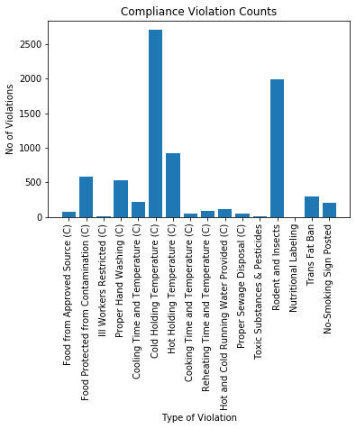

```python
# Plotting the required bar graph for the data frame in 2.1
plt.xlabel('Type of Violation')
plt.ylabel('No of Violations')
plt.title('Compliance Violation Counts')
plt.xticks(rotation='vertical')
plt.bar(x=violation_df['Type of Violation'], height=violation_df['No of Violations']);
```

### 3.2

```python
# Creating a Data Frame to store the establishments that are Restaurants
food_viz_df = food_inspection_data_dummy[food_inspection_data_dummy.Is_Restaurant == 'Y'].reset_index()
```

```python
# Sorting the Data Frame by Inspection Year-Month
food_viz_df = food_viz_df.sort_values(by='Inspection Year/Month')
```

```python
convert = {'Inspection Year/Month': str}
food_viz_df = food_viz_df.astype(convert)
```

```python
# Group by the inspection year- month
year_month_grouped = food_viz_df.groupby('Inspection Year/Month')
```

```python
# Creating a new Data Frame to store the values needed for the line graph
line_graph_df = pd.DataFrame(columns = ['Year_Month','Total Restaurants Inspected','Restaurants Out of Conpliance','Percentage of Restaurants Our of Compliance'])
```

```python
# Storing the unique Year Months into the Data Frame
line_graph_df['Year_Month'] = food_viz_df['Inspection Year/Month'].unique()
```

```python
# Working with the grouped data frame to get the required statistics and values
w=0
for name, group in year_month_grouped:
    total_Restaurants = year_month_grouped.get_group(name)['Establishment ID'].count()
    total_out_of_compliance = year_month_grouped.get_group(name)[year_month_grouped.get_group(name)['Is_Out_of_Compliance']=='1']['Establishment ID'].count()
    line_graph_df.iloc[w, 1] = total_Restaurants
    line_graph_df.iloc[w, 2] = total_out_of_compliance
    line_graph_df.iloc[w, 3] = (total_out_of_compliance/total_Restaurants)*100
    w += 1
```

```python
# Preview of the new Data Frame created for plotting a line graph
line_graph_df.head()
```

|  | Year_Month | Total Restaurants Inspected | Restaurants Out of Conpliance | Percentage of Restaurants Our of Compliance |
| --- | --- | --- | --- | --- |
| 0 | 2017-09 | 402 | 228 | 56.7164 |
| 1 | 2017-10 | 425 | 211 | 49.6471 |
| 2 | 2017-11 | 422 | 192 | 45.4976 |
| 3 | 2017-12 | 414 | 189 | 45.6522 |
| 4 | 2018-01 | 496 | 212 | 42.7419 |

```
[]
```

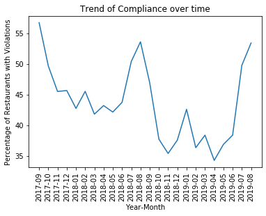

```python
# Plotting a line graph
plt.plot(line_graph_df['Year_Month'],line_graph_df['Percentage of Restaurants Our of Compliance']);
plt.xlabel('Year-Month')
plt.ylabel('Percentage of Restaurants with Violations')
plt.title('Trend of Compliance over time')
plt.xticks(rotation='vertical')
plt.plot()
```

The percentage of defaulting restaurants follows a cyclic pattern as the time goes by. The inspections find more violations after an almost equal amount of time. The lowest values are seen in April, 2019 where only ~34% of the restaurants were found non compliant. Thus, based on the vizualization, it could be said that the inspections become stricter and then easier in a cyclic pattern or the restaurants try and be more compliant at a certain time of the year always.

### 3.3

```python
# Grouping by Establishment ID
restaurant_grouped = food_viz_df.groupby('Establishment ID')
```

```python
# Create a new Data Frame to create a map
map_df = pd.DataFrame(columns = ['Establishment ID', 'lattitude', 'longitude','No of Food from Approved Source (C) violations', 'No of Food Protected from Contamination (C) violations','No of Ill Workers Restricted (C) violations','No of Proper Hand Washing (C) violations','No of Cooling Time and Temperature (C) violations','No of Cold Holding Temperature (C) violations', 'No of Hot Holding Temperature (C) violations','No of Cooking Time and Temperature (C) violations','No of Reheating Time and Temperature (C) violations','No of Hot and Cold Running Water Provided (C) violations','No of Proper Sewage Disposal (C) violations','No of Toxic Substances & Pesticides violations','No of Rodent and Insects violations','No of Nutritional Labeling violations','No of Trans Fat Ban violations','No of No-Smoking Sign Posted violations','Total No of Compliance Violations'])
```

```python
# Entering the unique Establishment IDs into the new Data Frame
map_df['Establishment ID'] = food_viz_df['Establishment ID'].unique()
```

```python
# Working with the grouped data frame to get the required statistics and values
z=0
for est_id, group in restaurant_grouped:
    total_violations = restaurant_grouped.get_group(est_id)['Number of Compliance Violations'].sum()
    total_food_approved_violations = restaurant_grouped.get_group(est_id)['Food from Approved Source (C) compliance'].sum()
    total_food_protected_violations = restaurant_grouped.get_group(est_id)['Food Protected from Contamination (C) compliance'].sum()
    total_workers_restricted_approved_violations = restaurant_grouped.get_group(est_id)['Ill Workers Restricted (C) compliance'].sum()
    total_hand_washing_violations = restaurant_grouped.get_group(est_id)['Proper Hand Washing (C) compliance'].sum()
    total_cooling_time_violations = restaurant_grouped.get_group(est_id)['Cooling Time and Temperature (C) compliance'].sum()
    total_cold_holding_violations = restaurant_grouped.get_group(est_id)['Cold Holding Temperature (C) compliance'].sum()
    total_hot_holding_violations = restaurant_grouped.get_group(est_id)['Hot Holding Temperature (C) compliance'].sum()
    total_cooking_time_violations = restaurant_grouped.get_group(est_id)['Cooking Time and Temperature (C) compliance'].sum()
    total_reheating_violations = restaurant_grouped.get_group(est_id)['Reheating Time and Temperature (C) compliance'].sum()
    total_hotandcold_running_violations = restaurant_grouped.get_group(est_id)['Hot and Cold Running Water Provided (C) compliance'].sum()
    total_sewage_violations = restaurant_grouped.get_group(est_id)['Proper Sewage Disposal (C) compliance'].sum()
    total_toxic_substances_violations = restaurant_grouped.get_group(est_id)['Toxic Substances & Pesticides compliance'].sum()
    total_rodent_violations = restaurant_grouped.get_group(est_id)['Rodent and Insects compliance'].sum()
    total_nutritional_violations = restaurant_grouped.get_group(est_id)['Nutritional Labeling compliance'].sum()
    total_trans_fat_violations = restaurant_grouped.get_group(est_id)['Trans Fat Ban compliance'].sum()
    total_nosmoking_sign_violations = restaurant_grouped.get_group(est_id)['No-Smoking Sign Posted compliance'].sum()
    latitude = restaurant_grouped.get_group(est_id)['Latitude'].unique()
    longitude = restaurant_grouped.get_group(est_id)['Longitude'].unique()

    map_df.iloc[z, 1] = latitude
    map_df.iloc[z, 2] = longitude
    map_df.iloc[z, 3] = total_food_approved_violations
    map_df.iloc[z, 4] = total_food_protected_violations
    map_df.iloc[z, 5] = total_workers_restricted_approved_violations
    map_df.iloc[z, 6] = total_hand_washing_violations
    map_df.iloc[z, 7] = total_cooling_time_violations
    map_df.iloc[z, 8] = total_cold_holding_violations
    map_df.iloc[z, 9] = total_hot_holding_violations
    map_df.iloc[z, 10] = total_cooking_time_violations
    map_df.iloc[z, 11] = total_reheating_violations
    map_df.iloc[z, 12] = total_hotandcold_running_violations
    map_df.iloc[z, 13] = total_sewage_violations
    map_df.iloc[z, 14] = total_toxic_substances_violations
    map_df.iloc[z, 15] = total_rodent_violations
    map_df.iloc[z, 16] = total_nutritional_violations
    map_df.iloc[z, 17] = total_trans_fat_violations
    map_df.iloc[z, 18] = total_nosmoking_sign_violations
    map_df.iloc[z, 19] = total_violations
    z += 1
```

```python
# Preview of the new Data Frame created for plotting a map
map_df.head()
```

|  | Establishment ID | lattitude | longitude | No of Food from Approved Source (C) violations | No of Food Protected from Contamination (C) violations | No of Ill Workers Restricted (C) violations | No of Proper Hand Washing (C) violations | No of Cooling Time and Temperature (C) violations | No of Cold Holding Temperature (C) violations | No of Hot Holding Temperature (C) violations | No of Cooking Time and Temperature (C) violations | No of Reheating Time and Temperature (C) violations | No of Hot and Cold Running Water Provided (C) violations | No of Proper Sewage Disposal (C) violations | No of Toxic Substances & Pesticides violations | No of Rodent and Insects violations | No of Nutritional Labeling violations | No of Trans Fat Ban violations | No of No-Smoking Sign Posted violations | Total No of Compliance Violations |
| --- | --- | --- | --- | --- | --- | --- | --- | --- | --- | --- | --- | --- | --- | --- | --- | --- | --- | --- | --- | --- |
| 0 | 29428 | 39.1177 | -77.1841 | 0 | 0 | 0 | 2 | 0 | 2 | 0 | 0 | 0 | 0 | 0 | 0 | 2 | 0 | 0 | 0 | 6 |
| 1 | 28889 | 39.0686 | -77.1309 | 0 | 0 | 0 | 0 | 0 | 1 | 0 | 0 | 0 | 0 | 0 | 0 | 0 | 0 | 0 | 0 | 1 |
| 2 | 71 | 39.1615 | -77.1597 | 1 | 0 | 0 | 1 | 1 | 1 | 1 | 0 | 0 | 0 | 0 | 0 | 0 | 0 | 0 | 0 | 5 |
| 3 | 17682 | 38.9792 | -77.0984 | 0 | 0 | 0 | 0 | 0 | 2 | 0 | 0 | 0 | 0 | 0 | 0 | 0 | 0 | 0 | 0 | 2 |
| 4 | 29588 | 39.0578 | -77.1127 | 0 | 0 | 0 | 0 | 0 | 0 | 0 | 0 | 0 | 0 | 0 | 0 | 0 | 0 | 0 | 0 | 0 |

```python
# Your mapbox token
mapbox_access_token = 'My Access Token Goes Here'
```

```python
# Plotting a Map using plotly to show the compliant and non complaint restaurants
class_map_data1 = go.Scattermapbox(
        lon = map_df[map_df['Total No of Compliance Violations'] == 0]['longitude'],
        lat = map_df[map_df['Total No of Compliance Violations'] == 0]['lattitude'],
        text = map_df[map_df['Total No of Compliance Violations'] == 0]['Establishment ID'],
        hoverinfo='text',
        mode = 'markers',
        marker = dict(
                    color = 'green',
                    symbol = 'circle',
                    opacity = .5
                ),
        name = "No Violations"
)

class_map_data2 = go.Scattermapbox(
        lon = map_df[map_df['Total No of Compliance Violations'] != 0]['longitude'],
        lat = map_df[map_df['Total No of Compliance Violations'] != 0]['lattitude'],
        text = map_df[map_df['Total No of Compliance Violations'] != 0]['Establishment ID'] ,
        hoverinfo='text',
        mode = 'markers',
        marker = dict(
                    color = 'red',
                    symbol = 'circle',
                    opacity = .5
                ),
        name = "Has made Violations"
)

class_map_layout = go.Layout(
        title = 'Compliant and non-compliant Restaurants',
        mapbox=go.layout.Mapbox(
            accesstoken=mapbox_access_token,
            zoom=1
        )
    )

class_map = go.Figure(data=[class_map_data1,class_map_data2], layout=class_map_layout)
class_map.show()
```

[interactive chart not shown]

We can see that most of the non-compliant restaurants are located in Silver Spring, Bethesda, Wheaton, Rockville, Gaithersburg and along the Rockville Pike road connecting North Bethesda and Rockville

```python
# Plotting a Map using plotly to show the compliant and non complaint restaurants
class_map_data1 = go.Scattermapbox(
        lon = map_df[map_df['No of Food from Approved Source (C) violations'] == 0]['longitude'],
        lat = map_df[map_df['No of Food from Approved Source (C) violations'] == 0]['lattitude'],
        text = map_df[map_df['No of Food from Approved Source (C) violations'] == 0]['Establishment ID'],
        hoverinfo='text',
        mode = 'markers',
        marker = dict(
                    color = 'blue',
                    symbol = 'circle',
                    opacity = .5
                ),
        name = "No Violations"
)

class_map_data2 = go.Scattermapbox(
        lon = map_df[map_df['No of Food from Approved Source (C) violations'] != 0]['longitude'],
        lat = map_df[map_df['No of Food from Approved Source (C) violations'] != 0]['lattitude'],
        text = map_df[map_df['No of Food from Approved Source (C) violations'] != 0]['Establishment ID'] ,
        hoverinfo='text',
        mode = 'markers',
        marker = dict(
                    color = 'red',
                    symbol = 'circle',
                    opacity = .5
                ),
        name = "Has made Violations"
)

class_map_layout = go.Layout(
        title = 'Compliant and non-compliant Restaurants for Food from Approved Source (C) violations',
        mapbox=go.layout.Mapbox(
            accesstoken=mapbox_access_token,
            zoom=1
        )
    )

class_map = go.Figure(data=[class_map_data1,class_map_data2], layout=class_map_layout)
class_map.show()
```

[interactive chart not shown]

There are very few restaurants that violate Food from Approved Source. They are scattered and do not show concentrations

```python
# Plotting a Map using plotly to show the compliant and non complaint restaurants
class_map_data1 = go.Scattermapbox(
        lon = map_df[map_df['No of Food Protected from Contamination (C) violations'] == 0]['longitude'],
        lat = map_df[map_df['No of Food Protected from Contamination (C) violations'] == 0]['lattitude'],
        text = map_df[map_df['No of Food Protected from Contamination (C) violations'] == 0]['Establishment ID'],
        hoverinfo='text',
        mode = 'markers',
        marker = dict(
                    color = 'blue',
                    symbol = 'circle',
                    opacity = .5
                ),
        name = "No Violations"
)

class_map_data2 = go.Scattermapbox(
        lon = map_df[map_df['No of Food Protected from Contamination (C) violations'] != 0]['longitude'],
        lat = map_df[map_df['No of Food Protected from Contamination (C) violations'] != 0]['lattitude'],
        text = map_df[map_df['No of Food Protected from Contamination (C) violations'] != 0]['Establishment ID'] ,
        hoverinfo='text',
        mode = 'markers',
        marker = dict(
                    color = 'red',
                    symbol = 'circle',
                    opacity = .5
                ),
        name = "Has made Violations"
)

class_map_layout = go.Layout(
        title = 'Compliant and non-compliant Restaurants for Food Protected from Contamination (C) violations',
        mapbox=go.layout.Mapbox(
            accesstoken=mapbox_access_token,
            zoom=1
        )
    )

class_map = go.Figure(data=[class_map_data1,class_map_data2], layout=class_map_layout)
class_map.show()
```

[interactive chart not shown]

Food Protected from Contamination violations are more common in Silver Spring, Bethesda, Rockville, Olney and Gaithersburg areas

```python
# Plotting a Map using plotly to show the compliant and non complaint restaurants
class_map_data1 = go.Scattermapbox(
        lon = map_df[map_df['No of Ill Workers Restricted (C) violations'] == 0]['longitude'],
        lat = map_df[map_df['No of Ill Workers Restricted (C) violations'] == 0]['lattitude'],
        text = map_df[map_df['No of Ill Workers Restricted (C) violations'] == 0]['Establishment ID'],
        hoverinfo='text',
        mode = 'markers',
        marker = dict(
                    color = 'blue',
                    symbol = 'circle',
                    opacity = .5
                ),
        name = "No Violations"
)

class_map_data2 = go.Scattermapbox(
        lon = map_df[map_df['No of Ill Workers Restricted (C) violations'] != 0]['longitude'],
        lat = map_df[map_df['No of Ill Workers Restricted (C) violations'] != 0]['lattitude'],
        text = map_df[map_df['No of Ill Workers Restricted (C) violations'] != 0]['Establishment ID'] ,
        hoverinfo='text',
        mode = 'markers',
        marker = dict(
                    color = 'red',
                    symbol = 'circle',
                    opacity = .5
                ),
        name = "Has made Violations"
)

class_map_layout = go.Layout(
        title = 'Compliant and non-compliant Restaurants for Ill Workers Restricted (C) violations',
        mapbox=go.layout.Mapbox(
            accesstoken=mapbox_access_token,
            zoom=1
        )
    )

class_map = go.Figure(data=[class_map_data1,class_map_data2], layout=class_map_layout)
class_map.show()
```

[interactive chart not shown]

There are very few restaurants that violate the ill Workers Restricted check. They are scattered and do not show concentrations

```python
# Plotting a Map using plotly to show the compliant and non complaint restaurants
class_map_data1 = go.Scattermapbox(
        lon = map_df[map_df['No of Proper Hand Washing (C) violations'] == 0]['longitude'],
        lat = map_df[map_df['No of Proper Hand Washing (C) violations'] == 0]['lattitude'],
        text = map_df[map_df['No of Proper Hand Washing (C) violations'] == 0]['Establishment ID'],
        hoverinfo='text',
        mode = 'markers',
        marker = dict(
                    color = 'blue',
                    symbol = 'circle',
                    opacity = .5
                ),
        name = "No Violations"
)

class_map_data2 = go.Scattermapbox(
        lon = map_df[map_df['No of Proper Hand Washing (C) violations'] != 0]['longitude'],
        lat = map_df[map_df['No of Proper Hand Washing (C) violations'] != 0]['lattitude'],
        text = map_df[map_df['No of Proper Hand Washing (C) violations'] != 0]['Establishment ID'] ,
        hoverinfo='text',
        mode = 'markers',
        marker = dict(
                    color = 'red',
                    symbol = 'circle',
                    opacity = .5
                ),
        name = "Has made Violations"
)

class_map_layout = go.Layout(
        title = 'Compliant and non-compliant Restaurants for Proper Hand Washing (C) violations',
        mapbox=go.layout.Mapbox(
            accesstoken=mapbox_access_token,
            zoom=1
        )
    )

class_map = go.Figure(data=[class_map_data1,class_map_data2], layout=class_map_layout)
class_map.show()
```

[interactive chart not shown]

There is some concentration of Proper Hand Washing Violations in Silver Spring, Bethesda, on Rockville Pike Road and Gaithersburg areas

```python
# Plotting a Map using plotly to show the compliant and non complaint restaurants
class_map_data1 = go.Scattermapbox(
        lon = map_df[map_df['No of Cooling Time and Temperature (C) violations'] == 0]['longitude'],
        lat = map_df[map_df['No of Cooling Time and Temperature (C) violations'] == 0]['lattitude'],
        text = map_df[map_df['No of Cooling Time and Temperature (C) violations'] == 0]['Establishment ID'],
        hoverinfo='text',
        mode = 'markers',
        marker = dict(
                    color = 'blue',
                    symbol = 'circle',
                    opacity = .5
                ),
        name = "No Violations"
)

class_map_data2 = go.Scattermapbox(
        lon = map_df[map_df['No of Cooling Time and Temperature (C) violations'] != 0]['longitude'],
        lat = map_df[map_df['No of Cooling Time and Temperature (C) violations'] != 0]['lattitude'],
        text = map_df[map_df['No of Cooling Time and Temperature (C) violations'] != 0]['Establishment ID'] ,
        hoverinfo='text',
        mode = 'markers',
        marker = dict(
                    color = 'red',
                    symbol = 'circle',
                    opacity = .5
                ),
        name = "Has made Violations"
)

class_map_layout = go.Layout(
        title = 'Compliant and non-compliant Restaurants for Cooling Time and Temperature (C) violations',
        mapbox=go.layout.Mapbox(
            accesstoken=mapbox_access_token,
            zoom=1
        )
    )

class_map = go.Figure(data=[class_map_data1,class_map_data2], layout=class_map_layout)
class_map.show()
```

[interactive chart not shown]

```python
# Plotting a Map using plotly to show the compliant and non complaint restaurants
class_map_data1 = go.Scattermapbox(
        lon = map_df[map_df['No of Cold Holding Temperature (C) violations'] == 0]['longitude'],
        lat = map_df[map_df['No of Cold Holding Temperature (C) violations'] == 0]['lattitude'],
        text = map_df[map_df['No of Cold Holding Temperature (C) violations'] == 0]['Establishment ID'],
        hoverinfo='text',
        mode = 'markers',
        marker = dict(
                    color = 'blue',
                    symbol = 'circle',
                    opacity = .5
                ),
        name = "No Violations"
)

class_map_data2 = go.Scattermapbox(
        lon = map_df[map_df['No of Cold Holding Temperature (C) violations'] != 0]['longitude'],
        lat = map_df[map_df['No of Cold Holding Temperature (C) violations'] != 0]['lattitude'],
        text = map_df[map_df['No of Cold Holding Temperature (C) violations'] != 0]['Establishment ID'] ,
        hoverinfo='text',
        mode = 'markers',
        marker = dict(
                    color = 'red',
                    symbol = 'circle',
                    opacity = .5
                ),
        name = "Has made Violations"
)

class_map_layout = go.Layout(
        title = 'Compliant and non-compliant Restaurants for Cold Holding Temperature (C) violations',
        mapbox=go.layout.Mapbox(
            accesstoken=mapbox_access_token,
            zoom=1
        )
    )

class_map = go.Figure(data=[class_map_data1,class_map_data2], layout=class_map_layout)
class_map.show()
```

[interactive chart not shown]

Cold Holding Temperature violations are observed in Bethesda, Silver Spring, olney and Wheaton. Also, there are violations observed along Rockville Pike road that connects Rockville with North Bethesda

```python
# Plotting a Map using plotly to show the compliant and non complaint restaurants
class_map_data1 = go.Scattermapbox(
        lon = map_df[map_df['No of Hot Holding Temperature (C) violations'] == 0]['longitude'],
        lat = map_df[map_df['No of Hot Holding Temperature (C) violations'] == 0]['lattitude'],
        text = map_df[map_df['No of Hot Holding Temperature (C) violations'] == 0]['Establishment ID'],
        hoverinfo='text',
        mode = 'markers',
        marker = dict(
                    color = 'blue',
                    symbol = 'circle',
                    opacity = .5
                ),
        name = "No Violations"
)

class_map_data2 = go.Scattermapbox(
        lon = map_df[map_df['No of Hot Holding Temperature (C) violations'] != 0]['longitude'],
        lat = map_df[map_df['No of Hot Holding Temperature (C) violations'] != 0]['lattitude'],
        text = map_df[map_df['No of Hot Holding Temperature (C) violations'] != 0]['Establishment ID'] ,
        hoverinfo='text',
        mode = 'markers',
        marker = dict(
                    color = 'red',
                    symbol = 'circle',
                    opacity = .5
                ),
        name = "Has made Violations"
)

class_map_layout = go.Layout(
        title = 'Compliant and non-compliant Restaurants for Hot Holding Temperature (C) violations',
        mapbox=go.layout.Mapbox(
            accesstoken=mapbox_access_token,
            zoom=1
        )
    )

class_map = go.Figure(data=[class_map_data1,class_map_data2], layout=class_map_layout)
class_map.show()
```

[interactive chart not shown]

Hot Holding Temperature violations are observed in Bethesda, Silver Spring and Wheaton. Also, there are violations observed along Rockville Pike road that connects Rockville with North Bethesda

```python
# Plotting a Map using plotly to show the compliant and non complaint restaurants
class_map_data1 = go.Scattermapbox(
        lon = map_df[map_df['No of Cooking Time and Temperature (C) violations'] == 0]['longitude'],
        lat = map_df[map_df['No of Cooking Time and Temperature (C) violations'] == 0]['lattitude'],
        text = map_df[map_df['No of Cooking Time and Temperature (C) violations'] == 0]['Establishment ID'],
        hoverinfo='text',
        mode = 'markers',
        marker = dict(
                    color = 'blue',
                    symbol = 'circle',
                    opacity = .5
                ),
        name = "No Violations"
)

class_map_data2 = go.Scattermapbox(
        lon = map_df[map_df['No of Cooking Time and Temperature (C) violations'] != 0]['longitude'],
        lat = map_df[map_df['No of Cooking Time and Temperature (C) violations'] != 0]['lattitude'],
        text = map_df[map_df['No of Cooking Time and Temperature (C) violations'] != 0]['Establishment ID'] ,
        hoverinfo='text',
        mode = 'markers',
        marker = dict(
                    color = 'red',
                    symbol = 'circle',
                    opacity = .5
                ),
        name = "Has made Violations"
)

class_map_layout = go.Layout(
        title = 'Compliant and non-compliant Restaurants for Cooking Time and Temperature (C) violations',
        mapbox=go.layout.Mapbox(
            accesstoken=mapbox_access_token,
            zoom=1
        )
    )

class_map = go.Figure(data=[class_map_data1,class_map_data2], layout=class_map_layout)
class_map.show()
```

[interactive chart not shown]

There are very few restaurants that violate the Cooking Time and Temperature check. They are scattered and do not show concentrations

```python
# Plotting a Map using plotly to show the compliant and non complaint restaurants
class_map_data1 = go.Scattermapbox(
        lon = map_df[map_df['No of Reheating Time and Temperature (C) violations'] == 0]['longitude'],
        lat = map_df[map_df['No of Reheating Time and Temperature (C) violations'] == 0]['lattitude'],
        text = map_df[map_df['No of Reheating Time and Temperature (C) violations'] == 0]['Establishment ID'],
        hoverinfo='text',
        mode = 'markers',
        marker = dict(
                    color = 'blue',
                    symbol = 'circle',
                    opacity = .5
                ),
        name = "No Violations"
)

class_map_data2 = go.Scattermapbox(
        lon = map_df[map_df['No of Reheating Time and Temperature (C) violations'] != 0]['longitude'],
        lat = map_df[map_df['No of Reheating Time and Temperature (C) violations'] != 0]['lattitude'],
        text = map_df[map_df['No of Reheating Time and Temperature (C) violations'] != 0]['Establishment ID'] ,
        hoverinfo='text',
        mode = 'markers',
        marker = dict(
                    color = 'red',
                    symbol = 'circle',
                    opacity = .5
                ),
        name = "Has made Violations"
)

class_map_layout = go.Layout(
        title = 'Compliant and non-compliant Restaurants for Reheating Time and Temperature (C) violations',
        mapbox=go.layout.Mapbox(
            accesstoken=mapbox_access_token,
            zoom=1
        )
    )

class_map = go.Figure(data=[class_map_data1,class_map_data2], layout=class_map_layout)
class_map.show()
```

[interactive chart not shown]

There are very few restaurants that violate the Reheating Time and Temperature check. They are scattered and do not show concentrations

```python
# Plotting a Map using plotly to show the compliant and non complaint restaurants
class_map_data1 = go.Scattermapbox(
        lon = map_df[map_df['No of Hot and Cold Running Water Provided (C) violations'] == 0]['longitude'],
        lat = map_df[map_df['No of Hot and Cold Running Water Provided (C) violations'] == 0]['lattitude'],
        text = map_df[map_df['No of Hot and Cold Running Water Provided (C) violations'] == 0]['Establishment ID'],
        hoverinfo='text',
        mode = 'markers',
        marker = dict(
                    color = 'blue',
                    symbol = 'circle',
                    opacity = .5
                ),
        name = "No Violations"
)

class_map_data2 = go.Scattermapbox(
        lon = map_df[map_df['No of Hot and Cold Running Water Provided (C) violations'] != 0]['longitude'],
        lat = map_df[map_df['No of Hot and Cold Running Water Provided (C) violations'] != 0]['lattitude'],
        text = map_df[map_df['No of Hot and Cold Running Water Provided (C) violations'] != 0]['Establishment ID'] ,
        hoverinfo='text',
        mode = 'markers',
        marker = dict(
                    color = 'red',
                    symbol = 'circle',
                    opacity = .5
                ),
        name = "Has made Violations"
)

class_map_layout = go.Layout(
        title = 'Compliant and non-compliant Restaurants for Cold Running Water Provided (C) violations',
        mapbox=go.layout.Mapbox(
            accesstoken=mapbox_access_token,
            zoom=1
        )
    )

class_map = go.Figure(data=[class_map_data1,class_map_data2], layout=class_map_layout)
class_map.show()
```

[interactive chart not shown]

There are very few restaurants that violate the Cold Running Water Provided check. They are scattered and do not show concentrations

```python
# Plotting a Map using plotly to show the compliant and non complaint restaurants
class_map_data1 = go.Scattermapbox(
        lon = map_df[map_df['No of Proper Sewage Disposal (C) violations'] == 0]['longitude'],
        lat = map_df[map_df['No of Proper Sewage Disposal (C) violations'] == 0]['lattitude'],
        text = map_df[map_df['No of Proper Sewage Disposal (C) violations'] == 0]['Establishment ID'],
        hoverinfo='text',
        mode = 'markers',
        marker = dict(
                    color = 'blue',
                    symbol = 'circle',
                    opacity = .5
                ),
        name = "No Violations"
)

class_map_data2 = go.Scattermapbox(
        lon = map_df[map_df['No of Proper Sewage Disposal (C) violations'] != 0]['longitude'],
        lat = map_df[map_df['No of Proper Sewage Disposal (C) violations'] != 0]['lattitude'],
        text = map_df[map_df['No of Proper Sewage Disposal (C) violations'] != 0]['Establishment ID'] ,
        hoverinfo='text',
        mode = 'markers',
        marker = dict(
                    color = 'red',
                    symbol = 'circle',
                    opacity = .5
                ),
        name = "Has made Violations"
)

class_map_layout = go.Layout(
        title = 'Compliant and non-compliant Restaurants for Sewage Disposal (C) violations',
        mapbox=go.layout.Mapbox(
            accesstoken=mapbox_access_token,
            zoom=1
        )
    )

class_map = go.Figure(data=[class_map_data1,class_map_data2], layout=class_map_layout)
class_map.show()
```

[interactive chart not shown]

There are very few restaurants that violate the Sewage Disposal check. They are scattered and do not show concentrations

```python
# Plotting a Map using plotly to show the compliant and non complaint restaurants
class_map_data1 = go.Scattermapbox(
        lon = map_df[map_df['No of Toxic Substances & Pesticides violations'] == 0]['longitude'],
        lat = map_df[map_df['No of Toxic Substances & Pesticides violations'] == 0]['lattitude'],
        text = map_df[map_df['No of Toxic Substances & Pesticides violations'] == 0]['Establishment ID'],
        hoverinfo='text',
        mode = 'markers',
        marker = dict(
                    color = 'blue',
                    symbol = 'circle',
                    opacity = .5
                ),
        name = "No Violations"
)

class_map_data2 = go.Scattermapbox(
        lon = map_df[map_df['No of Toxic Substances & Pesticides violations'] != 0]['longitude'],
        lat = map_df[map_df['No of Toxic Substances & Pesticides violations'] != 0]['lattitude'],
        text = map_df[map_df['No of Toxic Substances & Pesticides violations'] != 0]['Establishment ID'] ,
        hoverinfo='text',
        mode = 'markers',
        marker = dict(
                    color = 'red',
                    symbol = 'circle',
                    opacity = .5
                ),
        name = "Has made Violations"
)

class_map_layout = go.Layout(
        title = 'Compliant and non-compliant Toxic Substances & Pesticides violations',
        mapbox=go.layout.Mapbox(
            accesstoken=mapbox_access_token,
            zoom=1
        )
    )

class_map = go.Figure(data=[class_map_data1,class_map_data2], layout=class_map_layout)
class_map.show()
```

[interactive chart not shown]

There are very few restaurants that violate the Toxic substances and Pesticides check. They are scattered and do not show concentrations

```python
# Plotting a Map using plotly to show the compliant and non complaint restaurants
class_map_data1 = go.Scattermapbox(
        lon = map_df[map_df['No of Rodent and Insects violations'] == 0]['longitude'],
        lat = map_df[map_df['No of Rodent and Insects violations'] == 0]['lattitude'],
        text = map_df[map_df['No of Rodent and Insects violations'] == 0]['Establishment ID'],
        hoverinfo='text',
        mode = 'markers',
        marker = dict(
                    color = 'blue',
                    symbol = 'circle',
                    opacity = .5
                ),
        name = "No Violations"
)

class_map_data2 = go.Scattermapbox(
        lon = map_df[map_df['No of Rodent and Insects violations'] != 0]['longitude'],
        lat = map_df[map_df['No of Rodent and Insects violations'] != 0]['lattitude'],
        text = map_df[map_df['No of Rodent and Insects violations'] != 0]['Establishment ID'] ,
        hoverinfo='text',
        mode = 'markers',
        marker = dict(
                    color = 'red',
                    symbol = 'circle',
                    opacity = .5
                ),
        name = "Has made Violations"
)

class_map_layout = go.Layout(
        title = 'Compliant and non-compliant Rodent and Insects violations',
        mapbox=go.layout.Mapbox(
            accesstoken=mapbox_access_token,
            zoom=1
        )
    )

class_map = go.Figure(data=[class_map_data1,class_map_data2], layout=class_map_layout)
class_map.show()
```

[interactive chart not shown]

Rodent and Insects violations are observed in Bethesda, Silver Spring and Wheaton. Also, there are violations observed along Rockville Pike road that connects Rockville with North Bethesda

```python
# Plotting a Map using plotly to show the compliant and non complaint restaurants
class_map_data1 = go.Scattermapbox(
        lon = map_df[map_df['No of Trans Fat Ban violations'] == 0]['longitude'],
        lat = map_df[map_df['No of Trans Fat Ban violations'] == 0]['lattitude'],
        text = map_df[map_df['No of Trans Fat Ban violations'] == 0]['Establishment ID'],
        hoverinfo='text',
        mode = 'markers',
        marker = dict(
                    color = 'blue',
                    symbol = 'circle',
                    opacity = .5
                ),
        name = "No Violations"
)

class_map_data2 = go.Scattermapbox(
        lon = map_df[map_df['No of Trans Fat Ban violations'] != 0]['longitude'],
        lat = map_df[map_df['No of Trans Fat Ban violations'] != 0]['lattitude'],
        text = map_df[map_df['No of Trans Fat Ban violations'] != 0]['Establishment ID'] ,
        hoverinfo='text',
        mode = 'markers',
        marker = dict(
                    color = 'red',
                    symbol = 'circle',
                    opacity = .5
                ),
        name = "Has made Violations"
)

class_map_layout = go.Layout(
        title = 'Compliant and non-compliant Trans Fat Ban violations',
        mapbox=go.layout.Mapbox(
            accesstoken=mapbox_access_token,
            zoom=1
        )
    )

class_map = go.Figure(data=[class_map_data1,class_map_data2], layout=class_map_layout)
class_map.show()
```

[interactive chart not shown]

Trans Fat Ban Violations are concentrated in Bethesda and Rockville areas

```python
# Plotting a Map using plotly to show the compliant and non complaint restaurants
class_map_data1 = go.Scattermapbox(
        lon = map_df[map_df['No of No-Smoking Sign Posted violations'] == 0]['longitude'],
        lat = map_df[map_df['No of No-Smoking Sign Posted violations'] == 0]['lattitude'],
        text = map_df[map_df['No of No-Smoking Sign Posted violations'] == 0]['Establishment ID'],
        hoverinfo='text',
        mode = 'markers',
        marker = dict(
                    color = 'blue',
                    symbol = 'circle',
                    opacity = .5
                ),
        name = "No Violations"
)

class_map_data2 = go.Scattermapbox(
        lon = map_df[map_df['No of No-Smoking Sign Posted violations'] != 0]['longitude'],
        lat = map_df[map_df['No of No-Smoking Sign Posted violations'] != 0]['lattitude'],
        text = map_df[map_df['No of No-Smoking Sign Posted violations'] != 0]['Establishment ID'] ,
        hoverinfo='text',
        mode = 'markers',
        marker = dict(
                    color = 'red',
                    symbol = 'circle',
                    opacity = .5
                ),
        name = "Has made Violations"
)

class_map_layout = go.Layout(
        title = 'Compliant and non-compliant No-Smoking Sign Posted violations',
        mapbox=go.layout.Mapbox(
            accesstoken=mapbox_access_token,
            zoom=1
        )
    )

class_map = go.Figure(data=[class_map_data1,class_map_data2], layout=class_map_layout)
class_map.show()
```

[interactive chart not shown]

The Non-Smoking sign violations are concentrated near Bethesda, Silver Spring, Rockville

```python
# Plotting a Map using plotly to show the compliant and non complaint restaurants
class_map_data1 = go.Scattermapbox(
        lon = map_df[map_df['No of Nutritional Labeling violations'] == 0]['longitude'],
        lat = map_df[map_df['No of Nutritional Labeling violations'] == 0]['lattitude'],
        text = map_df[map_df['No of Nutritional Labeling violations'] == 0]['Establishment ID'],
        hoverinfo='text',
        mode = 'markers',
        marker = dict(
                    color = 'blue',
                    symbol = 'circle',
                    opacity = .5
                ),
        name = "No Violations"
)

class_map_data2 = go.Scattermapbox(
        lon = map_df[map_df['No of Nutritional Labeling violations'] != 0]['longitude'],
        lat = map_df[map_df['No of Nutritional Labeling violations'] != 0]['lattitude'],
        text = map_df[map_df['No of Nutritional Labeling violations'] != 0]['Establishment ID'] ,
        hoverinfo='text',
        mode = 'markers',
        marker = dict(
                    color = 'red',
                    symbol = 'circle',
                    opacity = .5
                ),
        name = "Has made Violations"
)

class_map_layout = go.Layout(
        title = 'Compliant and non-compliant Nutritional Labeling violations',
        mapbox=go.layout.Mapbox(
            accesstoken=mapbox_access_token,
            zoom=1
        )
    )

class_map = go.Figure(data=[class_map_data1,class_map_data2], layout=class_map_layout)
class_map.show()
```

[interactive chart not shown]

The restaurants have made least violations in displaying the nutritional value of the food products.

From the first Map that shows violating and non- violating restaurants we can see that the violators are concentrated in below regions ,

1. Silver Spring
2. Bethesda
3. Wheaton
4. Rockville Pike Road
5. Gaithersburg

From the above graphs for individual violations we are able to notice that the violations that contribute greatly to the trend observed in violating restaurants are as follows,

1. Food Protected from Contamination
2. Proper Hand Washing
3. Cold Holding Temperature
4. Hot Holding Temperatur
5. Rodent and Insects violations
6. Trans Fat Ban
7. The Non-Smoking sign

We also observe that these violators are concentrated in the same areas as observed from the first map. Thus, confirming our findings from the map.